# Analiza graczy Osu!

2024-11-05

[figure not shown]

Akademia Górniczo-Hutnicza im. Stanisława Staszica w Krakowie  
Wydział Zarządzania  
Statystyczna analiza danych

Projekt: Analiza graczy Osu!

Miłosz Polinceusz  
Statystyczna analiza danych  
Studia niestacjonarne  
Semestr V

# 1. Analiza danych.

Odczyt danych z pliku csv:

```r
file_path <- "osuPlayers.csv"
osu_data <- read.csv(file_path, header = TRUE, sep = ",")
osu_data$celnosc <- as.numeric(sub("%", "", osu_data$celnosc))
```

W ramach wstępnej analizy przeprowadzimy kilka prostych działań na naszych danych, aby odpowiedzieć na kluczowe pytania. Spodziewamy się, że część graczy mogła doświadczyć zablokowania swojego konta, co może wprowadzić niepożądane zakłócenia w naszych wynikach. W związku z tym, usuniemy wartości odstające, które jasno wskażą, których graczy należy wykluczyć z analizy.

Dodatkowo, zbadamy korelację między liczbą zdobytych medali a celnością graczy. Wiele osób zakłada, że zawodnicy turniejowi, zdobywający największą liczbę medali, charakteryzują się większą regularnością, co powinno przekładać się na wyższą celność. Przeanalizujemy, czy nasze dane potwierdzają tę tezę.

Sprawdzimy także, czy popularne hasło „play more” przekłada się na lepsze wyniki. Zbadamy, czy niektórzy gracze zmagają się z tzw. „mindblockiem”, który może utrudniać im osiąganie lepszych rezultatów.

```r
library(knitr)
library(kableExtra)

osu_data %>%
  kable("html", escape = FALSE) %>%
  kable_styling(full_width = FALSE)
```

| ranking | nazwa.gracza | celnosc | liczba.zagran | liczba.pp | Ocena.SS | Ocena.S | Ocena.A | ilosc.medali |
| --- | --- | --- | --- | --- | --- | --- | --- | --- |
| 1 | mrekk | 97.96 | 201441 | 28448 | 63 | 1547 | 1681 | 17 |
| 2 | 9MlCE | 97.96 | 328421 | 27381 | 38 | 981 | 1702 | 5 |
| 3 | lifeline | 97.66 | 257107 | 24024 | 170 | 3191 | 2688 | 5 |
| 4 | NINERIK | 98.68 | 175403 | 23586 | 199 | 1178 | 1261 | 13 |
| 5 | gnahus | 99.05 | 146752 | 22803 | 647 | 3067 | 1240 | 11 |
| 6 | Ivaxa | 97.20 | 94462 | 21785 | 41 | 742 | 1178 | 0 |
| 7 | Chicony | 98.53 | 66656 | 21777 | 0 | 527 | 1824 | 7 |
| 8 | aimbotcone | 97.78 | 187065 | 21731 | 28 | 756 | 2159 | 1 |
| 9 | sytho | 97.48 | 364186 | 21532 | 156 | 643 | 729 | 0 |
| 10 | aknzx | 97.98 | 84619 | 21042 | 15 | 459 | 962 | 1 |
| 11 | WindowLife | 98.76 | 162401 | 20993 | 33 | 653 | 1125 | 3 |
| 12 | Flaro | 97.84 | 144717 | 20913 | 113 | 667 | 990 | 0 |
| 13 | NyanPotato | 96.90 | 171666 | 20601 | 15 | 476 | 677 | 0 |
| 14 | Kamensh1k | 97.70 | 122758 | 20515 | 83 | 1538 | 1377 | 5 |
| 15 | Lexu2S | 98.40 | 96854 | 20486 | 20 | 367 | 701 | 0 |
| 16 | ASecretBox | 99.15 | 257397 | 20367 | 71 | 935 | 1832 | 8 |
| 17 | enri | 98.91 | 241870 | 20315 | 405 | 1416 | 1723 | 14 |
| 18 | yamss | 97.67 | 256235 | 20293 | 30 | 704 | 1591 | 2 |
| 19 | tomasz chic | 98.09 | 148490 | 20269 | 54 | 324 | 826 | 2 |
| 20 | aetrna | 97.95 | 165149 | 20147 | 141 | 649 | 1154 | 0 |
| 21 | shimon | 98.50 | 278125 | 20099 | 104 | 1080 | 2081 | 0 |
| 22 | Utami | 98.25 | 154271 | 20080 | 207 | 1107 | 1019 | 16 |
| 23 | ChocoPafe | 97.99 | 232910 | 20042 | 90 | 1498 | 1976 | 0 |
| 24 | WhiteCat | 98.61 | 51051 | 20007 | 70 | 607 | 1073 | 9 |
| 25 | FlyingTuna | 97.94 | 145949 | 19933 | 53 | 1155 | 1261 | 32 |
| 26 | femboygaming | 98.20 | 49530 | 19879 | 2 | 323 | 905 | 0 |
| 27 | hydrogen bomb | 99.21 | 156223 | 19873 | 111 | 993 | 763 | 22 |
| 28 | kazamabc | 98.76 | 324249 | 19872 | 198 | 2169 | 2397 | 0 |
| 29 | MALISZEWSKI | 98.95 | 146924 | 19865 | 2909 | 5331 | 856 | 55 |
| 30 | Freddie Benson | 98.66 | 91815 | 19854 | 17 | 604 | 1199 | 1 |
| 31 | Shyot73 | 97.47 | 134296 | 19744 | 30 | 1342 | 2069 | 0 |
| 32 | MINHOCA LOKA | 97.74 | 202619 | 19731 | 25 | 527 | 1083 | 0 |
| 33 | Milkteaism | 98.43 | 127659 | 19619 | 394 | 1239 | 1567 | 1 |
| 34 | creator | 98.05 | 266898 | 19528 | 52 | 839 | 1438 | 3 |
| 35 | Mathi | 99.13 | 257152 | 19469 | 183 | 3006 | 2233 | 11 |
| 36 | ciru | 97.96 | 256667 | 19372 | 77 | 642 | 1116 | 0 |
| 37 | Rafis | 98.85 | 380502 | 19326 | 238 | 2755 | 2229 | 4 |
| 38 | [Karcher] | 99.27 | 195015 | 19215 | 228 | 1999 | 1581 | 14 |
| 39 | xootynator | 99.40 | 102069 | 19195 | 112 | 1644 | 1969 | 23 |
| 40 | worst hr player | 98.61 | 130282 | 19165 | 143 | 1358 | 891 | 13 |
| 41 | Connor McDavid | 98.83 | 277245 | 19116 | 291 | 3967 | 2355 | 13 |
| 42 | Aricin | 98.83 | 187612 | 19086 | 90 | 1700 | 2205 | 2 |
| 43 | Saiyku | 98.25 | 177450 | 19059 | 74 | 1086 | 1873 | 4 |
| 44 | Zylice | 97.02 | 115257 | 18995 | 56 | 797 | 2227 | 9 |
| 45 | bored yes | 97.87 | 105113 | 18822 | 30 | 680 | 666 | 0 |
| 46 | [MG]Arnold24x24 | 98.82 | 186442 | 18795 | 856 | 2389 | 1344 | 15 |
| 47 | reused | 98.62 | 148542 | 18756 | 59 | 719 | 2628 | 0 |
| 48 | VoProSSoFF | 98.64 | 224146 | 18739 | 94 | 1004 | 1668 | 0 |
| 49 | Egor | 97.87 | 90779 | 18728 | 11 | 348 | 874 | 0 |
| 50 | Welter | 98.87 | 181990 | 18697 | 53 | 1566 | 1926 | 5 |

```r
#odchylenia standardowe
sd(osu_data$`liczba.zagran`)
```

```
## [1] 78701.22
```

```r
sd(osu_data$`liczba.pp`)
```

```
## [1] 1946.989
```

Wyniki analizy odchyleń standardowych liczby zagrań sugerują, że w naszej próbce danych znajdują się gracze, którzy otrzymali bana w trakcie swojej kariery. Zidentyfikujmy tych graczy i wyeliminujmy ich z analizy. Wykorzystamy wykres punktowy, aby lepiej zobrazować, którzy zawodnicy byli w przeszłości zbanowani.

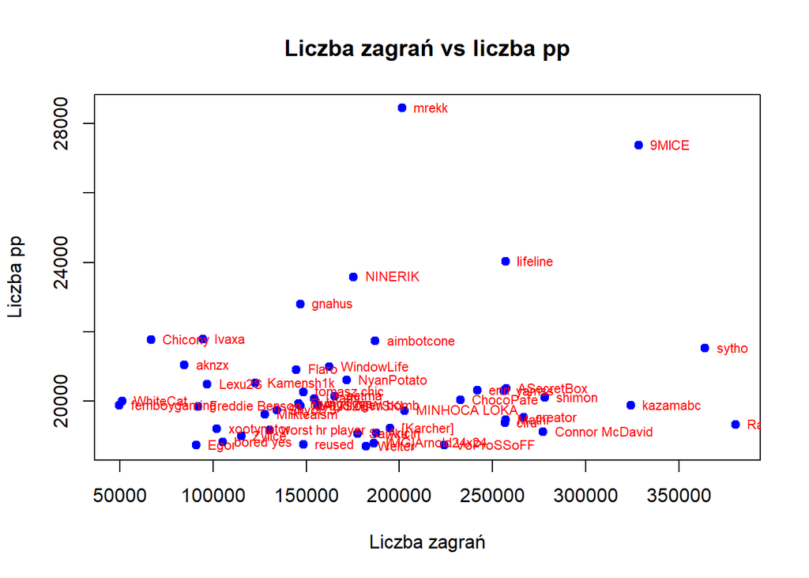

```r
# Tworzenie wykresu rozrzutu
plot(osu_data$`liczba.zagran`, osu_data$`liczba.pp`,
     xlab = "Liczba zagrań", ylab = "Liczba pp",
     main = "Liczba zagrań vs liczba pp", pch = 19, col = "blue")

# Dodawanie nazw graczy do wykresu
text(osu_data$`liczba.zagran`, osu_data$`liczba.pp`,
     labels = osu_data$`nazwa.gracza`, pos = 4, cex = 0.7, col = "red")
```

Na wykresie widać, że gracze “WhiteCat”, “femboygaming” oraz “Chicony” mają nadzwyczaj małą liczbę zagrań jak na zawodników znajdujących się w top 50 na świecie. Zgadza się, są to osoby, które wcześniej otrzymały bana, co może wpłynąć na naszą analizę. Odrzucimy ich dane, aby nie zaburzały dalszych wyników.

```r
osu_data <- subset(osu_data, !nazwa.gracza %in% c("WhiteCat", "femboygaming", "Chicony"))
```

Dodatkowo, zauważamy, że największe skupisko najlepszych graczy na świecie znajduje się wśród tych z około 150,000 zagrań. Widać również graczy, takich jak “Rafis”, “sytho” oraz “kazamabc”, którzy mimo dużej liczby zagrań nie zdobywają znaczącej ilości punktów pp. Może to wynikać z faktu, że koncentrują się oni bardziej na grze turniejowej niż na zdobywaniu punktów. Sprawdźmy, jak wygląda ich stosunek zdobytych medali do liczby zagrań.

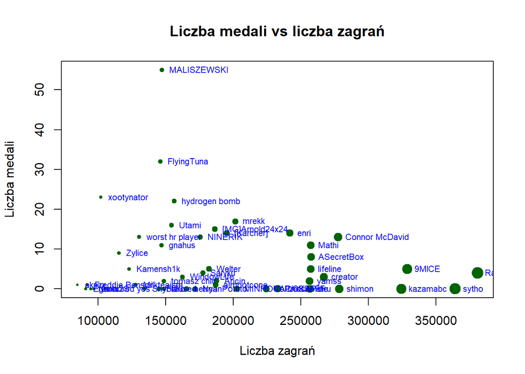

```r
# Wykres rozrzutu dla liczby medali a liczby zagrań
plot(osu_data$`liczba.zagran`, osu_data$`ilosc.medali`,
     xlab = "Liczba zagrań", ylab = "Liczba medali",
     main = "Liczba medali vs liczba zagrań",
     pch = 19, col = "darkgreen", cex = osu_data$`liczba.zagran` / max(osu_data$`liczba.zagran`) * 2)

# Dodanie nazw graczy
text(osu_data$`liczba.zagran`, osu_data$`ilosc.medali`,
     labels = osu_data$`nazwa.gracza`, pos = 4, cex = 0.7, col = "blue")
```

Niestety, jak pokazuje powyższy wykres, gracze “Rafis”, “sytho” oraz “kazamabc” nie są zawodnikami turniejowymi, co skutkuje dużą ilością czasu spędzanego na grze bez znaczących efektów. Zjawisko znane w społeczności osu jako “mindblock” może przeszkadzać w osiąganiu lepszych wyników, a mimo większej liczby rozegranych gier, niektórzy gracze mogą nie poprawić swojego rankingu. Na wykresie dostrzegamy również nowych zawodników: “MALISZEWSKI”, “FlyingTuna” oraz “xootynator”, którzy wydają się koncentrować głównie na grach turniejowych. Na wcześniejszym wykresie ich nazwy użytkownika były trudne do zauważenia.

Sprawdźmy teraz, czy gracze turniejowi rzeczywiście charakteryzują się wyższą celnością w porównaniu do tych, którzy koncentrują się na zdobywaniu punktów pp.

```r
cor(osu_data$`ilosc.medali`, osu_data$`celnosc`)
```

```
## [1] 0.402591
```

Korelacja między liczbą medali a celnością jest umiarkowana i dodatnia, co sugeruje, że gracze zdobywający więcej medali mają tendencję do osiągania wyższej celności. Ten wynik potwierdza nasze wcześniejsze założenia. Sprawdźmy jednak, jak wyniki prezentują się po podziale na graczy rankingowych i turniejowych.

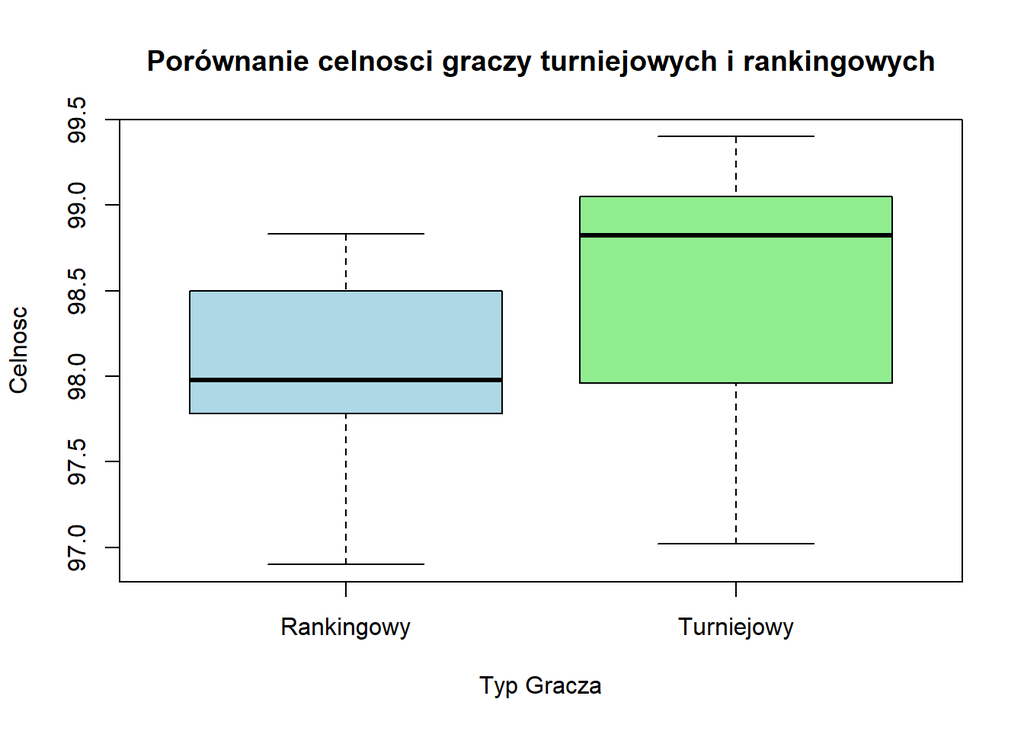

```r
osu_data_klasy<-osu_data
osu_data_klasy$typ_gracza <- ifelse(osu_data$ilosc.medali < 4, "Rankingowy", "Turniejowy")
boxplot(celnosc ~ typ_gracza, data = osu_data_klasy,
        main = "Porównanie celnosci graczy turniejowych i rankingowych",
        xlab = "Typ Gracza",
        ylab = "Celnosc",
        col = c("lightblue", "lightgreen"))
```

Wyniki potwierdzają naszą tezę: gracze turniejowi mają wyższą celność. Różnica jest zaskakująco duża. Jak pokazuje wykres, dolny kwartyl celności graczy turniejowych osiąga poziom mediany celności graczy rankingowych, co sugeruje, że nawet najmniej celni zawodnicy w grupie turniejowej osiągają wyniki porównywalne z medianą graczy rankingowych. To wskazuje na wyraźną przewagę graczy turniejowych w zakresie celności, co może wynikać z intensywniejszego treningu oraz większej ekspozycji na rywalizację w turniejach.

Wracając do pełnej próbki danych, sprawdźmy korelację między liczbą zagrań a punktami pp. Wciąż jesteśmy ciekawi, czy większa liczba rozegranych gier przekłada się na lepsze wyniki.

```r
cor(osu_data$`liczba.zagran`, osu_data$`liczba.pp`)
```

```
## [1] 0.1892324
```

Korelacja między liczbą zagrań a punktami pp jest niska, co oznacza, że nie istnieje silna zależność między tymi dwoma zmiennymi. Innymi słowy, gracze, którzy spędzają więcej czasu na grze, niekoniecznie zdobywają więcej punktów. Sugeruje to, że inne czynniki mogą mieć większy wpływ na osiągane wyniki, a liczba zagrań nie jest dobrym wskaźnikiem punktów.

Oczywiście zakładamy, że celem każdego gracza jest zdobycie jak największej liczby punktów, jednak to założenie może nie być trafne. Sprawdźmy, jak korelacje prezentują się w podziale graczy na turniejowych i rankingowych.

```r
gracze_turniejowi <- osu_data_klasy[osu_data_klasy$typ_gracza == "Turniejowy", ]

# Wydzielenie graczy rankingowych
gracze_rankingowi <- osu_data_klasy[osu_data_klasy$typ_gracza == "Rankingowy", ]

# Sprawdzenie korelacji między ilością medali a ilością zagran dla graczy turniejowych
korelacja_medali_zagran <- cor( gracze_turniejowi$liczba.zagran, gracze_turniejowi$ilosc.medali, use = "complete.obs")
cat("Korelacja między ilością medali a ilością zagran dla graczy turniejowych:", korelacja_medali_zagran, "\n")
```

```
## Korelacja między ilością medali a ilością zagran dla graczy turniejowych: -0.3911428
```

```r
# Sprawdzenie korelacji między punktami pp a ilością zagran dla graczy rankingowych
korelacja_pp_zagran <- cor(gracze_rankingowi$liczba.pp, gracze_rankingowi$liczba.zagran, use = "complete.obs")
cat("Korelacja między punktami pp a ilością zagran dla graczy rankingowych:", korelacja_pp_zagran, "\n")
```

```
## Korelacja między punktami pp a ilością zagran dla graczy rankingowych: 0.04533697
```

Ujemna korelacja między liczbą medali a liczbą zagrań sugeruje, że graczom turniejowym wystarcza mniej zagrań, aby osiągać dobre wyniki, podczas gdy wśród graczy rankingowych nie widzimy wyraźnej zależności. Prawdopodobnie oznacza to, że poświęcanie większej ilości czasu na grę nie prowadzi do znaczącego wzrostu punktów pp. Na podstawie uzyskanych wyników korelacji można zauważyć, że system rankingowy, który faworyzuje zdobywanie punktów pp, może niewłaściwie określać poziom umiejętności graczy. Dlatego w dalszej części analizy, wykorzystując porządkowanie liniowe danych, postaramy się stworzyć własny ranking. Dodatkowo, podczas analizy skupień podzielimy graczy na grupy, aby zbadać zależności między ich stylami gry.

Aby kontynuować analizę danych, spróbujemy zwizualizować nasze dane na kilka sposobów, co pomoże nam lepiej je zrozumieć.

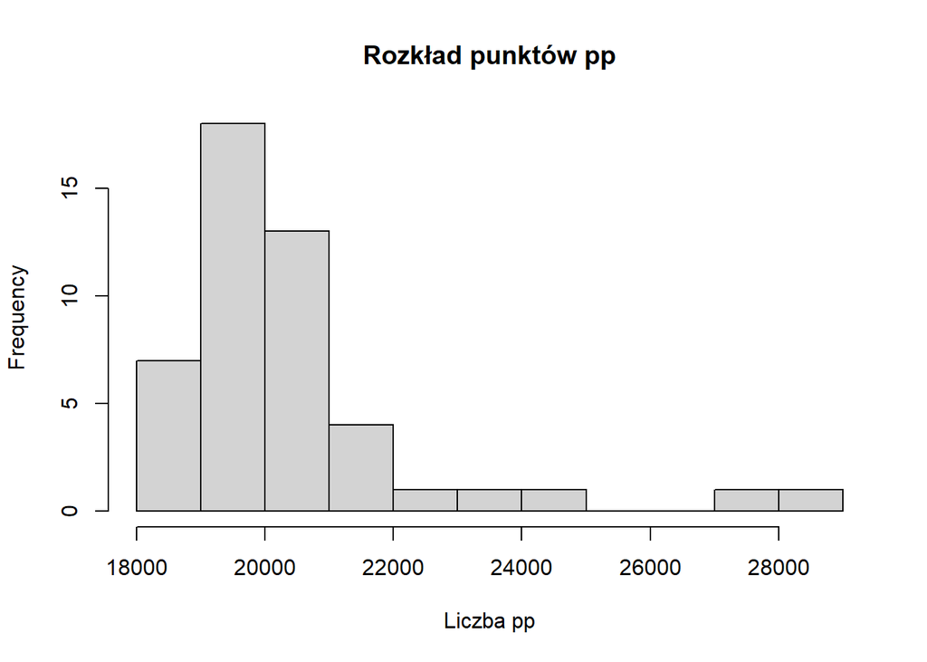

```r
hist(osu_data$`liczba.pp`, main="Rozkład punktów pp", xlab="Liczba pp")
```

Na powyższym histogramie widzimy rozkład punktów pp, który bardzo przypomina rozkład chi2. Nasz rozkład cechuje się dużą asymetrią prawostronną. Świadczy to o tym, że w rankingu top 50 mogą znajdować się gracze, którzy osiągają bardzo wysokie wyniki, co prowadzi do koncentracji danych w górnej części rozkładu. W takim przypadku, wiele osób może mieć wyniki bliskie średniej, a tylko nieliczni gracze osiągają wyniki znacznie powyżej średniej, co tworzy charakterystyczny kształt. Dodatkowo punkty pp w osu! są obliczane na podstawie złożoności rozgrywek, osiągniętych wyników oraz dokładności gracza. Taki system może sprzyjać tworzeniu większych wartości punktowych dla wybitnych graczy, co może skutkować kształtem asymetrią rozkładu.

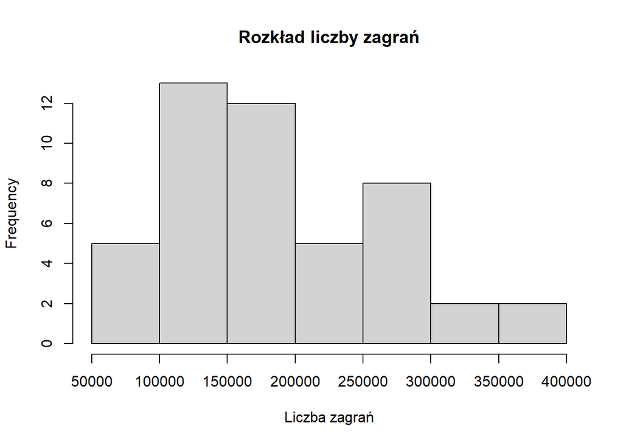

```r
hist(osu_data$`liczba.zagran`, main="Rozkład liczby zagrań", xlab="Liczba zagrań")
```

Histogram rozkładu liczby zagrań potwierdza to, co zauważyliśmy wcześniej na wykresie punktowym. Większość graczy z top 50 ma liczbę zagrań w okolicach 150 000. Zakładając, że średnia długość jednego zagrania wynosi 2 minuty, aby osiągać wybitne wyniki, należy poświęcić co najmniej 5 000 godzin na grę, co odpowiada aż 208 dniom nieprzerwanego grania.

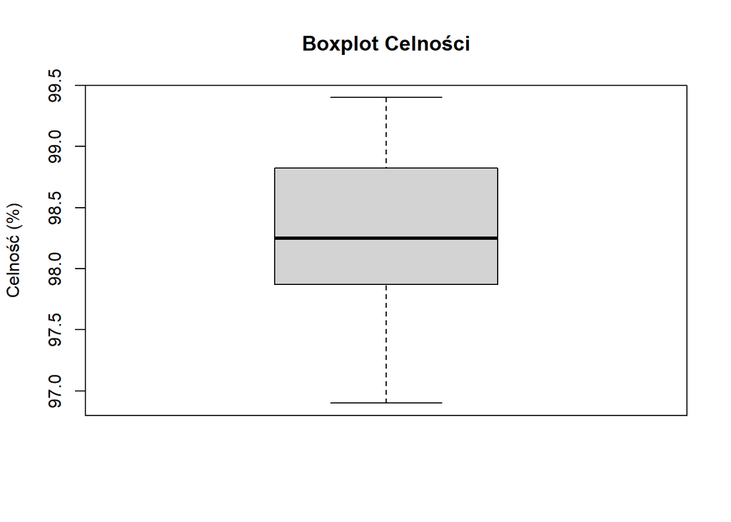

```r
boxplot(osu_data$`celnosc`, main="Boxplot Celności", ylab="Celność (%)")
```

W kolejnych krokach skupimy się na bardziej szczegółowej analizie, aby zbudować własny ranking graczy oraz utworzyć podział danych na grupy.

# 2. Porządkowanie liniowe

Analizując wcześniejsze wnioski, możemy stwierdzić, że aktualny ranking nie jest odpowiednią miarą umiejętności gracza. Utworzymy teraz nowy ranking, który uwzględni większą liczbę zmiennych.

Korzystając z zależności, że popełnienie najmniejszego błędu w jednym zagraniu skutkuje zmianą oceny z S na A, możemy stworzyć wskaźnik stresu, którym będzie stosunek ocen A do ocen S. Dzięki temu wskaźnikowi sprawdzimy, jak często gracze popełniają błędy podczas swoich zagrań. Im niższy wskaźnik stresu, tym spokojniejszy styl gry gracza. Użyjemy tego wskaźnika jako destymulanta, ponieważ chcemy, aby w naszym rankingu wysoko plasowali się gracze z niskim wskaźnikiem stresu.

Załóżmy, że najlepszym graczem będzie osoba o najwyższej liczbie: punktów pp, medali, celności, oraz o najniższej ilości: wskaźnika stresu, liczbie zagrań.

Dlaczego nie bierzemy pod uwagę Ocen SS? Ocena SS świadczy o celności jednego zagrania na 100%. W naszej analizie danych już bierzemy pod uwagę kryterium celności. Dodatkowo liczbą ocen SS można bardzo łatwo manipulować, więc nie jest to miarodajny parametr w naszej analizie.

Dlaczego traktujemy liczbę zagrań jako destymulanta? Chcemy faworyzować w naszym rankingu graczy, którzy osiągnęli lepsze wyniki w krótszym czasie.

```r
# Dodanie kolumny wskaznik.radzenia.sobie.ze.stresem z zabezpieczeniem przed dzieleniem przez zero
osu_data$wskaznik.stresu <- with(osu_data, ifelse(Ocena.A == 0, NA,  Ocena.A / Ocena.S))

osu_data <- subset(osu_data, !nazwa.gracza %in% c("WhiteCat", "femboygaming", "Chicony"))

# Kopiujemy oryginalne dane, aby zachować je bez modyfikacji
osu_data_original <- osu_data

# Ustalmy stymulanty i destymulanty
stimulants <- c("celnosc", "liczba.pp", "ilosc.medali")
destimulants <- c("wskaznik.stresu", "liczba.zagran")

# 1. Przekształcenie destymulantów na stymulanty w kopii danych
osu_data[destimulants] <- lapply(osu_data[destimulants], function(x) max(x) - x)

# 2. Standaryzacja danych
standardized_data <- as.data.frame(scale(osu_data[, c(stimulants, destimulants)]))

# 3. Wyznaczenie wzorca
pattern <- apply(standardized_data, 2, max)

# 4. Obliczenie odległości euklidesowej od wzorca
distances <- apply(standardized_data, 1, function(row) sqrt(sum((row - pattern)^2)))

# 5. Miara Hellwiga
H_measure <- 1 - distances / max(distances)

# Dodanie miary Hellwiga do kopii oryginalnych danych
osu_data_original$Hellwig_measure <- H_measure

# Posortowanie danych według miary Hellwiga
osu_data_sorted <- osu_data_original[order(-osu_data_original$Hellwig_measure), ]

# Dodanie kolumny "nowy ranking" jako kolejność według miary Hellwiga
osu_data_sorted$nowy.ranking <- seq_len(nrow(osu_data_sorted))

# Utworzenie kolumny nowy_ranking
osu_data_sorted <- osu_data_sorted[, c("nowy.ranking", setdiff(names(osu_data_sorted), c("nowy.ranking", "ranking")))]
osu_data_sorted <- osu_data_sorted[, setdiff(names(osu_data_sorted), c("Ocena.SS", "Ocena.S", "Ocena.A"))]

library(knitr)
library(kableExtra)

osu_data_sorted %>%
  kable("html", escape = FALSE) %>%
  kable_styling(full_width = FALSE)
```

|  | nowy.ranking | nazwa.gracza | celnosc | liczba.zagran | liczba.pp | ilosc.medali | wskaznik.stresu | Hellwig_measure |
| --- | --- | --- | --- | --- | --- | --- | --- | --- |
| 29 | 1 | MALISZEWSKI | 98.95 | 146924 | 19865 | 55 | 0.1605702 | 0.4993640 |
| 1 | 2 | mrekk | 97.96 | 201441 | 28448 | 17 | 1.0866193 | 0.4593542 |
| 4 | 3 | NINERIK | 98.68 | 175403 | 23586 | 13 | 1.0704584 | 0.4162946 |
| 5 | 4 | gnahus | 99.05 | 146752 | 22803 | 11 | 0.4043039 | 0.4133064 |
| 27 | 5 | hydrogen bomb | 99.21 | 156223 | 19873 | 22 | 0.7683787 | 0.3792136 |
| 25 | 6 | FlyingTuna | 97.94 | 145949 | 19933 | 32 | 1.0917749 | 0.3714395 |
| 39 | 7 | xootynator | 99.40 | 102069 | 19195 | 23 | 1.1976886 | 0.3502927 |
| 22 | 8 | Utami | 98.25 | 154271 | 20080 | 16 | 0.9205059 | 0.3127306 |
| 17 | 9 | enri | 98.91 | 241870 | 20315 | 14 | 1.2168079 | 0.2909043 |
| 38 | 10 | [Karcher] | 99.27 | 195015 | 19215 | 14 | 0.7908954 | 0.2866361 |
| 40 | 11 | worst hr player | 98.61 | 130282 | 19165 | 13 | 0.6561119 | 0.2827519 |
| 46 | 12 | [MG]Arnold24x24 | 98.82 | 186442 | 18795 | 15 | 0.5625785 | 0.2754745 |
| 3 | 13 | lifeline | 97.66 | 257107 | 24024 | 5 | 0.8423692 | 0.2666699 |
| 35 | 14 | Mathi | 99.13 | 257152 | 19469 | 11 | 0.7428476 | 0.2482353 |
| 2 | 15 | 9MlCE | 97.96 | 328421 | 27381 | 5 | 1.7349643 | 0.2464116 |
| 11 | 16 | WindowLife | 98.76 | 162401 | 20993 | 3 | 1.7228178 | 0.2343731 |
| 41 | 17 | Connor McDavid | 98.83 | 277245 | 19116 | 13 | 0.5936476 | 0.2339116 |
| 14 | 18 | Kamensh1k | 97.70 | 122758 | 20515 | 5 | 0.8953186 | 0.2202140 |
| 16 | 19 | ASecretBox | 99.15 | 257397 | 20367 | 8 | 1.9593583 | 0.2107659 |
| 50 | 20 | Welter | 98.87 | 181990 | 18697 | 5 | 1.2298851 | 0.1885660 |
| 33 | 21 | Milkteaism | 98.43 | 127659 | 19619 | 1 | 1.2647296 | 0.1882502 |
| 15 | 22 | Lexu2S | 98.40 | 96854 | 20486 | 0 | 1.9100817 | 0.1809826 |
| 12 | 23 | Flaro | 97.84 | 144717 | 20913 | 0 | 1.4842579 | 0.1806167 |
| 42 | 24 | Aricin | 98.83 | 187612 | 19086 | 2 | 1.2970588 | 0.1759940 |
| 10 | 25 | aknzx | 97.98 | 84619 | 21042 | 1 | 2.0958606 | 0.1744169 |
| 30 | 26 | Freddie Benson | 98.66 | 91815 | 19854 | 1 | 1.9850993 | 0.1735369 |
| 6 | 27 | Ivaxa | 97.20 | 94462 | 21785 | 0 | 1.5876011 | 0.1569869 |
| 43 | 28 | Saiyku | 98.25 | 177450 | 19059 | 4 | 1.7246777 | 0.1548813 |
| 20 | 29 | aetrna | 97.95 | 165149 | 20147 | 0 | 1.7781202 | 0.1467540 |
| 23 | 30 | ChocoPafe | 97.99 | 232910 | 20042 | 0 | 1.3190921 | 0.1439301 |
| 45 | 31 | bored yes | 97.87 | 105113 | 18822 | 0 | 0.9794118 | 0.1353916 |
| 19 | 32 | tomasz chic | 98.09 | 148490 | 20269 | 2 | 2.5493827 | 0.1297092 |
| 28 | 33 | kazamabc | 98.76 | 324249 | 19872 | 0 | 1.1051176 | 0.1281302 |
| 34 | 34 | creator | 98.05 | 266898 | 19528 | 3 | 1.7139452 | 0.1216448 |
| 21 | 35 | shimon | 98.50 | 278125 | 20099 | 0 | 1.9268519 | 0.1211706 |
| 31 | 36 | Shyot73 | 97.47 | 134296 | 19744 | 0 | 1.5417288 | 0.1190928 |
| 48 | 37 | VoProSSoFF | 98.64 | 224146 | 18739 | 0 | 1.6613546 | 0.1173276 |
| 8 | 38 | aimbotcone | 97.78 | 187065 | 21731 | 1 | 2.8558201 | 0.1136993 |
| 37 | 39 | Rafis | 98.85 | 380502 | 19326 | 4 | 0.8090744 | 0.1083975 |
| 32 | 40 | MINHOCA LOKA | 97.74 | 202619 | 19731 | 0 | 2.0550285 | 0.0975370 |
| 13 | 41 | NyanPotato | 96.90 | 171666 | 20601 | 0 | 1.4222689 | 0.0956048 |
| 36 | 42 | ciru | 97.96 | 256667 | 19372 | 0 | 1.7383178 | 0.0943684 |
| 18 | 43 | yamss | 97.67 | 256235 | 20293 | 2 | 2.2599432 | 0.0925009 |
| 9 | 44 | sytho | 97.48 | 364186 | 21532 | 0 | 1.1337481 | 0.0857705 |
| 49 | 45 | Egor | 97.87 | 90779 | 18728 | 0 | 2.5114943 | 0.0632373 |
| 44 | 46 | Zylice | 97.02 | 115257 | 18995 | 9 | 2.7942284 | 0.0500603 |
| 47 | 47 | reused | 98.62 | 148542 | 18756 | 0 | 3.6550765 | 0.0000000 |

Po zaimplementowaniu porządkowania liniowego na naszych danych możemy zauważyć, że na pierwszym miejscu znajduje się gracz o nazwie użytkownika “MALISZEWSKI”. Jest to niewątpliwie najlepszy zawodnik turniejowy, posiadający aż 55 medali. Jak widać, poprzedni ranking niesłusznie faworyzował graczy z największą ilością punktów pp. Choć punkty pp są istotnym stymulantem, motywującym graczy do ciągłego postępu, ich faworyzowanie może być krzywdzące dla zawodników, którzy dysponują szerszym zakresem umiejętności niż tylko zdobywanie punktów. Wśród pierwszej dziesiątki wyróżniają się tacy gracze jak “xootynator” czy “[Karcher]”, którzy w poprzednim rankingu zajmowali odpowiednio miejsca 39 i 38.

# 3. Analiza skupień

Jak już wcześniej zauważyliśmy, nasze dane można podzielić na graczy turniejowych oraz rankingowych. Sprawdźmy, czy korzystając z metody k-średnich, uzyskamy taki podział.

Najpierw, przy użyciu metody łokcia, określimy liczbę klastrów dla naszego grupowania.

```r
library(factoextra)
```

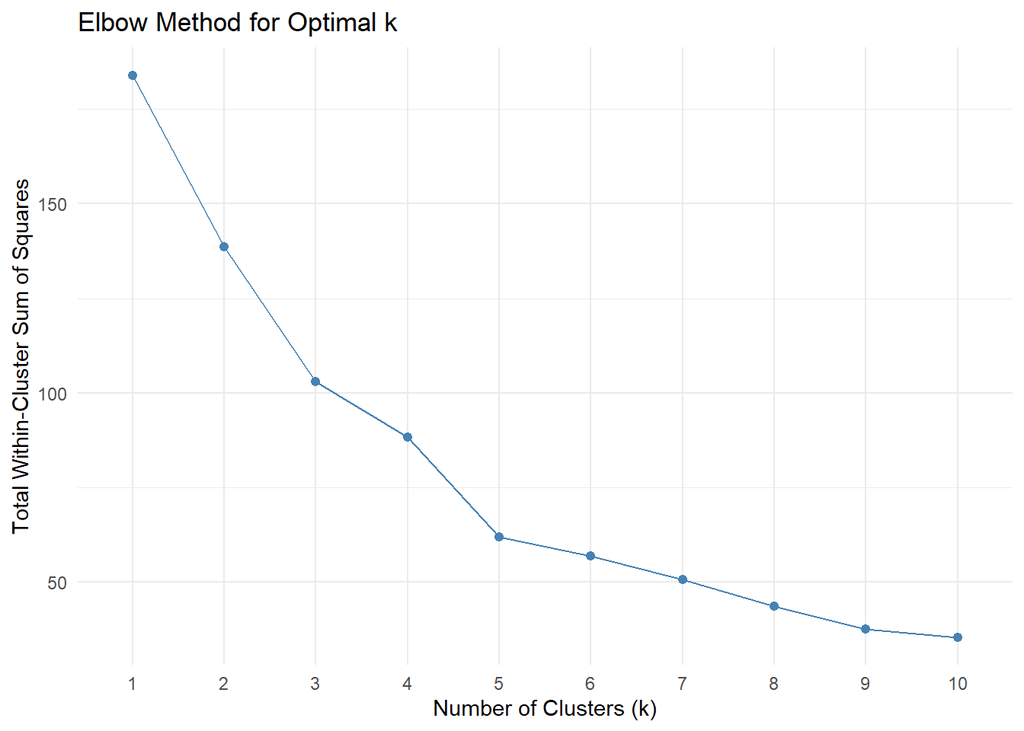

```r
library(ggplot2)
library(magrittr)
osu_data <- subset(osu_data, !nazwa.gracza %in% c("WhiteCat", "femboygaming", "Chicony"))
osu_data_cluster <- osu_data %>%
  dplyr::select(celnosc, liczba.zagran, liczba.pp, ilosc.medali)
osu_data_normalized <- scale(osu_data_cluster)
set.seed(123)
# Zakres klastrów
k_values <- 1:10

# Za pomooca metody łokcia (wss) sprawdzamy ilość klastrów
fviz_nbclust(osu_data_normalized, kmeans, method = "wss") +
  labs(title = "Elbow Method for Optimal k", x = "Number of Clusters (k)", y = "Total Within-Cluster Sum of Squares") +
  theme_minimal()
```

Na podstawie powyższego wykresu można stwierdzić, że optymalnym wyborem będą 3 klastry. Po ich wybraniu przechodzimy do dalszej analizy, wizualizując nasze dane przy użyciu metody k-średnich.

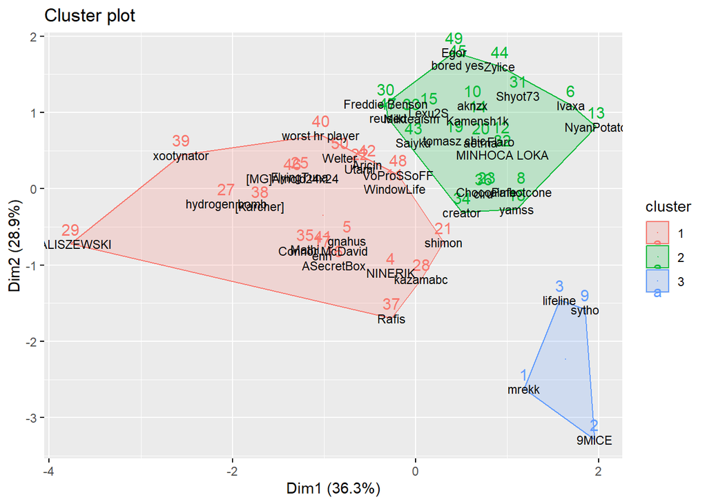

```r
kmeans_result <- kmeans(osu_data_normalized, centers = 3, nstart = 20) #3 klastry
osu_data$cluster <- as.factor(kmeans_result$cluster)
fviz_cluster(kmeans_result, osu_data_cluster, geom = "text") +
  geom_text(aes(label = osu_data$nazwa.gracza), color = "black", size = 3)
```

Dane zostały podzielone na 3 grupy.

Grupa nr 2 to gracze z najniższą celnością oraz stosunkowo niskim rankingiem.

W wyniku analizy dane podzieliły się na 3 grupy. Widać wyraźny podział na graczy rankingowych oraz turniejowych, jednak pojawiła się także niespodziewana grupa rankingowych graczy, którzy osiągają gorsze wyniki niż ci najlepsi.

Sprawdźmy teraz za pomocą metody macierzy odległości, czy taki podział jest trafny. Upewnijmy się, że gracze można podzielić w sposób, który udało nam się dotychczas zaobserwować.

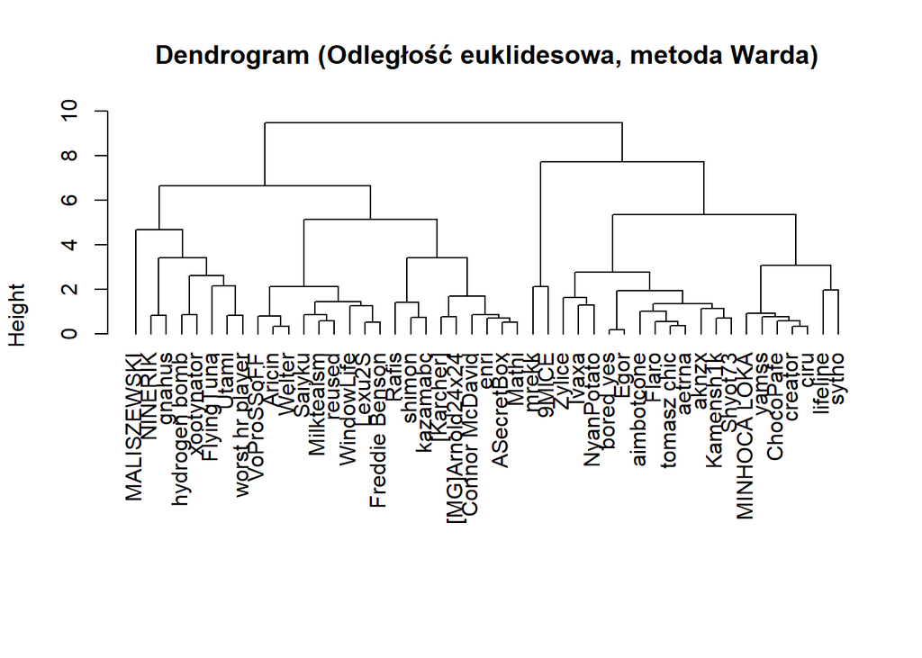

```r
# Wyznaczenie macierzy odległości
dist_euclidean <- dist(osu_data_normalized, method = "euclidean")

# Grupowanie z wykorzystaniem metody Warda
ward_euclidean <- hclust(dist_euclidean, method = "ward.D2")

# Wizualizacja wyników w postaci dendrogramu z etykietami graczy
plot(ward_euclidean,
     main = "Dendrogram (Odległość euklidesowa, metoda Warda)",
     xlab = "",
     sub = "",
     hang = -1,
     labels = osu_data$nazwa.gracza) # Zmienione etykiety
```

Rzeczywiście, potwierdzają się nasze wcześniejsze założenia. Po lewej stronie pierwsza gałąź charakteryzuje się graczami o wyższej celności oraz większej liczbie medali. Natomiast prawa strona obejmuje graczy o niższej celności i wyższej liczbie punktów rankingowych.

# 4.Podsumowując naszą analizę danych:

W naszej analizie graczy osu! dokonaliśmy kilku istotnych obserwacji, które rzucają światło na złożoność osiąganych wyników w tej grze:  
- Graczy można podzielić na turniejowych i rankingowych.  
- Ranking oparty na punktach pp może być niewiarygodny w ocenie najlepszych graczy.  
- Zasada “play more” nie zawsze przynosi efekty; niektórzy gracze mogą zmagać się z “mindblockiem”, co utrudnia postęp mimo dużego poświęcenia.  
- Aby osiągać światowe wyniki w grze Osu!, należy łączyć talent z dużym nakładem czasu.  
- Gracze pragnący poprawić swoją celność powinni skupić się na rozgrywkach turniejowych zamiast na zdobywaniu rankingu.